# Lecture 1: Why macroeconomics?

Macro I

Dr Theo Arvanitopoulos

# EC114: Introductory Macroeconomics

**Macro I**

EC114 follows EC113 and completes your first-year introduction to economics.

It studies economy-wide growth, unemployment and inflation, and what government policy can do about them.

### Why macroeconomics?

We will use evidence, diagrams and mathematics to connect individual decisions with economy-wide outcomes.

We will also ask when markets coordinate activity well and when government action may improve economic performance.

**Our starting question:** how do millions of individual choices become economy-wide outcomes?

Module overview: [University of Reading, EC114 description (2026/27)](https://www.reading.ac.uk/modules/documents?acyear=2026%252f7&modcode=EC114&schoolcode=PPE+ECO%7CPPE+GIPIS%7CPPE+PHIL%7CPPE+POL).

# Module structure

### 1. Timings

**Autumn lectures (weeks 7–11):** Mondays, 11:00 am–1:00 pm, in JJ Thomson, Slingo Lecture Theatre (LG01). The first is Monday 9 November 2026.

**Spring lectures (weeks 1–5):** check your second-semester timetable for the time and room.

**Tutorials:** one each teaching week from week 8; check your timetable for your group and room.

### 2. Assessment

**Mock online test (0%):** Friday 11 December 2026, to practise the format.

**Online test 1 (20%):** Tuesday 15 December 2026, available 06:00–18:00 on Blackboard; covers Lectures 1–4.

**Online test 2 (20%):** Wednesday 10 March 2027; covers Lectures 6–9.

**Final exam (60%):** three-hour, in-person written exam, between 10 and 24 May 2027.

# Module map

**Semester 1:** lectures 1–5. **Semester 2:** lectures 6–10.

| Lecture | Topic |
| --- | --- |
| 1 | Why macroeconomics? Basic concepts and ideas in macroeconomics |
| 2 | Micro foundations: scarcity, supply, demand, and equilibrium |
| 3 | The circular flow and GDP |
| 4 | Inflation, unemployment, and interest rates |
| 5 | Goods markets: consumption, investment, and equilibrium output |
| 6 | Goods markets: government and fiscal policy |
| 7 | Money markets: money, central banks, and interest rates |
| 8 | Output, the price level, and the interest rate |
| 9 | Policy and shocks: fiscal and monetary policy, inflation, and supply shocks |
| 10 | The labour market and the Phillips curve |

# Learning objectives

By the end of this lecture, you should be able to:

- explain the questions that distinguish macroeconomics from microeconomics;
- describe the main aggregate outcomes and read levels, growth rates and log-scale plots;
- explain why the Great Depression changed economic thought;
- distinguish classical, Keynesian, and later macroeconomic approaches;
- describe how modern macroeconomists connect models with evidence.

### 📚 Reading

Case, Fair and Oster, *Principles of Macroeconomics*, Chapters 1 and 5.

# Lecture outline

1. **Introduction:** what macroeconomics asks and why aggregation matters.
2. **The economy in data:** output, growth, logs, unemployment, and inflation.
3. **How ideas changed:** from market clearing to Keynes and later approaches.
4. **The course ahead:** models, evidence, and the questions we will study.

We begin with the outcomes we want to explain, then ask how economists came to explain them.

# The organising question

> Why can an economy contain capable workers, productive firms and useful technology, yet still experience recession, unemployment or inflation?

Macroeconomics studies how individual decisions interact through markets, institutions and policy to produce aggregate outcomes.

# The economist’s toolkit

Economics provides a disciplined way to analyse choices under constraints.

- opportunity cost;
- decisions at the margin;
- the coordinating role of markets;
- models that isolate a mechanism using *ceteris paribus*.

These tools help us understand individual choices.

**Macroeconomics asks what happens when those choices interact across the whole economy.**

# Microeconomics and macroeconomics

| Microeconomics | Macroeconomics |
| --- | --- |
| individual households, firms and markets | totals across the economy |
| a product’s relative price | the overall price level and inflation |
| employment in a firm or industry | economy-wide employment and unemployment |
| allocation within markets | interaction across goods, labour and financial markets |

Macroeconomics builds on individual behaviour but cannot study each market in isolation.

# When individual choices add up

One household can save more by spending less, holding everyone else’s spending and income constant.

If *every* household cuts spending together, firms may sell less, reduce production and lower employment.

$\rightarrow$ Household income can then fall, making it harder for the economy as a whole to save more.

The action remains individually sensible, but its aggregate consequence depends on how other agents respond.

This is an example of the **paradox of thrift**: an individually sensible decision need not have the same effect when made by everyone.

It is a possibility, not a claim that saving is always harmful.

# Three central concerns

### Output and growth

How much does the economy produce, and how does productive capacity change?

### Unemployment

Why can people willing and able to work remain without jobs?

### Inflation

Why does the overall price level rise, and why does inflation vary?

Each outcome describes a different part of economic performance.

A country can, for example, have rising output while unemployment remains high or inflation accelerates.

# Business cycles

[figure not shown]

- **Business cycle:** expansions and contractions (recessions) in economy-wide activity around a longer-run trend.
- **Beyond GDP:** employment, production, and financial conditions often move together. Cycles differ in cause, severity, and duration.
- **Turning points:** notice when indicators change direction around peaks and low points. Keynes linked investment and employment in his analysis of the *trade cycle* ([1936, ch. 22](https://www.hetwebsite.net/het/texts/keynes/gt/chap22.htm)).

# Levels and rates of change

The **level** tells us how much is produced at a point in time. The **growth rate** tells us how quickly that level changes.

During a recovery, output can still be low even though it is growing. At the start of a downturn, output can still be high even though it is falling.

For output $Y$, the annual percentage growth rate is

$$g_t =
\frac{Y_t-Y_{t-1}}{Y_{t-1}}\times100$$

Here $Y_t$ is output this year and $Y_{t-1}$ is output last year. For example, a rise from 100 to 103 gives $g_t=3\%$.

# What is a logarithm?

An exponent tells us the result of raising a base to a power: $10^2=100$.

A logarithm asks the reverse question: **which power of 10 gives 100?**

$$\log_{10}(100)=2
\quad\text{because}\quad 10^2=100.$$

- The small number in $\log_b(x)$ is the **base**. In general, $\log_b(x)=y$ means $b^y=x$.
- Base 10 gives $\log_{10}(x)$. The **natural log** uses base $e\approx2.718$ and is written $\ln(x)=\log_e(x)$.
- In these slides, “log” means the natural log. We take logs only of **positive** values.

# Why economists use logs

Economists often compare **proportional changes**, rather than differences in units. Logs help because a percentage change in a positive variable is close to a change in its natural log:

$$100[\ln(Y_t)-\ln(Y_{t-1})]\ \approx\
g_t.$$

For example, output rising from 100 to 105 grows by **exactly 5%**. The log calculation gives $100[\ln(105)-\ln(100)]\approx4.88\%$. It is an approximation, especially for larger changes.

On a log plot, equal vertical distances represent equal **proportional** changes.

$\rightarrow$ That makes the long-run output series on the next slide easier to read.

# A long view of UK output

Growth over centuries is not a smooth line.

What matters here is the sustained rise in output after industrialisation, rather than any single year’s movement.

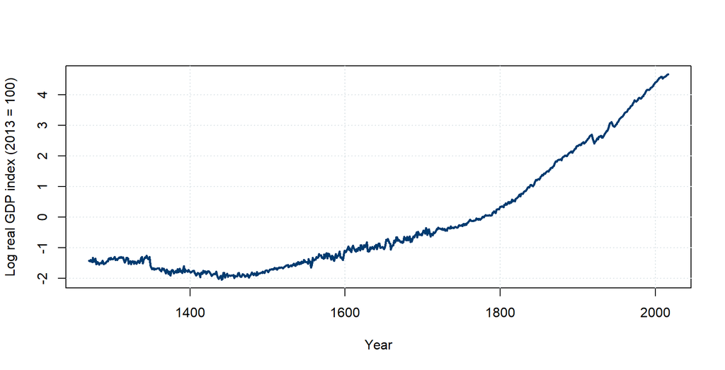

Source: Bank of England, *A Millennium of Macroeconomic Data*. The historical series combines English and geographically consistent UK estimates; a log scale makes proportional changes easier to compare.

# Modern UK real GDP

The historical view gives way to an official annual series.

**Real GDP** measures output after adjusting for changes in prices.

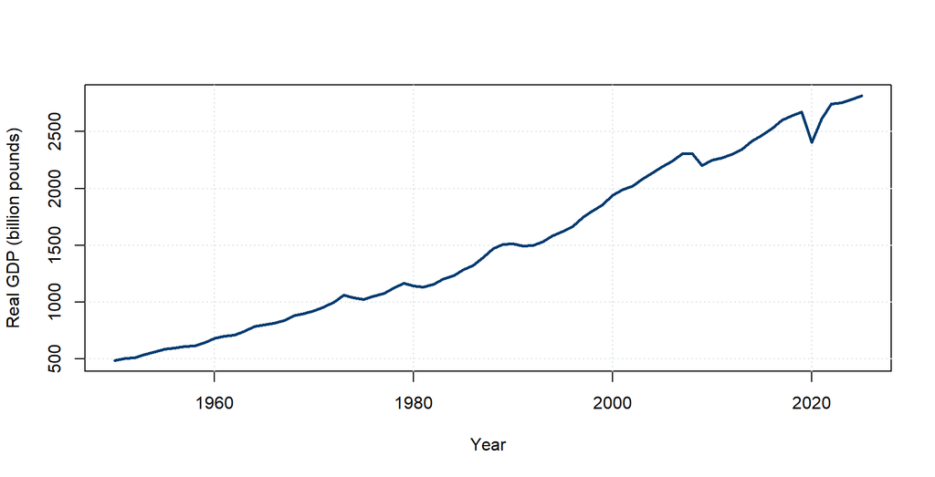

Source: Office for National Statistics (ONS), series ABMI. Read the vertical axis as the level of inflation-adjusted output, not as its growth rate.

# UK real GDP growth

The same output series tells a different story when we plot **year-to-year percentage change**.

**Orange dots** mark years of negative annual growth: real GDP fell compared with the previous year.

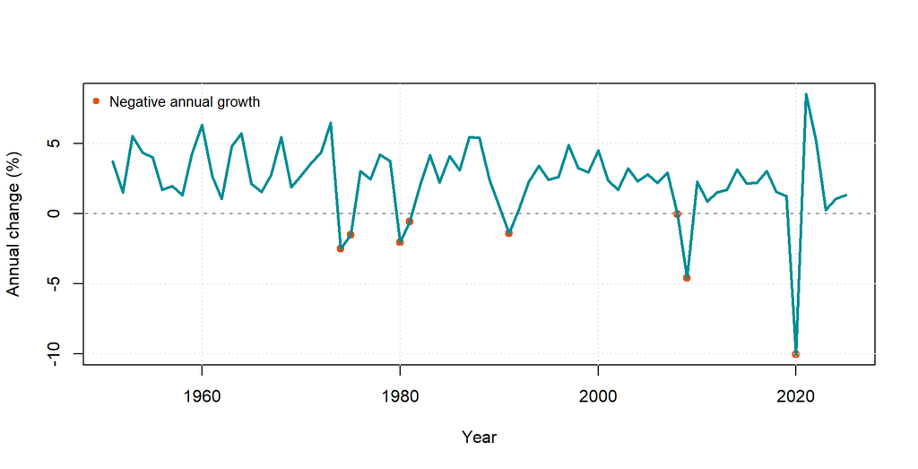

Source: ONS, series ABMI; growth calculated from annual real GDP. Orange points mark negative annual growth.

# UK unemployment

Unemployment counts people without work who are seeking and available for work.

The **unemployment rate** expresses that group as a share of the labour force, rather than the whole population.

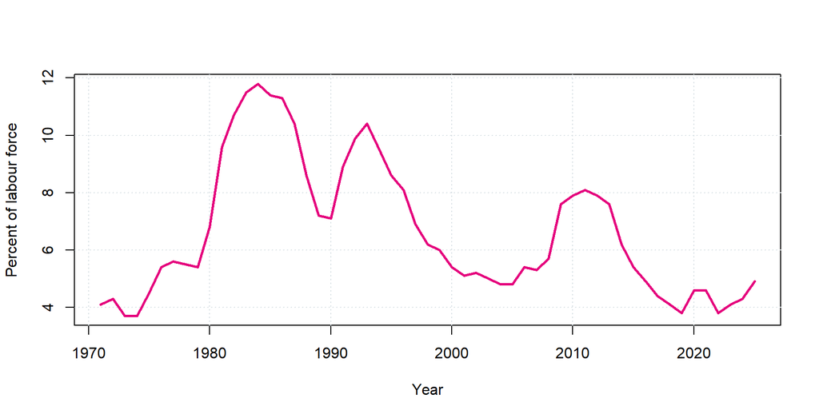

Source: ONS, series MGSX. The unemployment rate can rise even while employment also rises if the labour force grows faster.

# UK inflation

**Inflation** is the rate at which the overall consumer price level rises.

A fall in inflation usually means prices are rising more slowly, not that prices are falling.

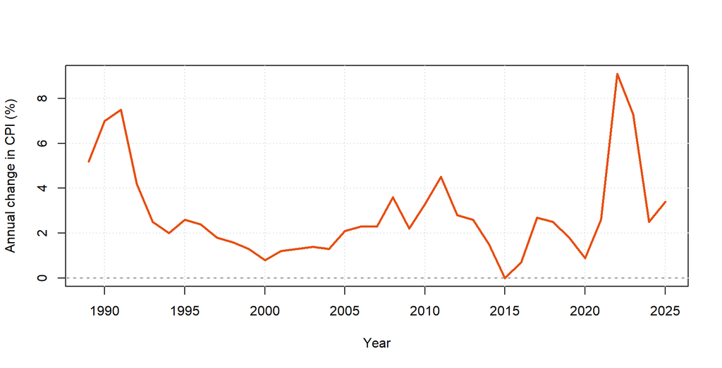

Source: ONS, series D7G7 (CPI 12-month rate). Values below zero indicate falling consumer prices.

# Why history matters

Economic theories respond to problems that existing explanations cannot resolve.

The history of macroeconomic thought therefore asks:

- What problem confronted economists?
- Which assumptions did the prevailing model make?
- What evidence challenged those assumptions?
- Which new mechanism or policy followed?

Theories develop through a continuing exchange between models and events.

# Before macroeconomics became a separate field

Before the 1930s, economists had studied production, distribution, trade and long-run growth, but macroeconomics was not yet a separate field.

[**Adam Smith (1776)**](https://www.econlib.org/library/Smith/smWN.html) explained how decentralised exchange and specialisation could coordinate activity through prices.

[**David Ricardo (1817)**](https://www.econlib.org/library/Ricardo/ricP.html) analysed distribution and comparative advantage.

[**Karl Marx (1867)**](https://www.marxists.org/archive/marx/works/1867-c1/) examined capital accumulation and class conflict, offering a critique of capitalism rather than an account centred on market coordination.

Later neoclassical economists, including [**William Stanley Jevons (1871)**](https://www.econlib.org/library/YPDBooks/Jevons/jvnPE.html), [**Francis Ysidro Edgeworth (1881)**](https://archive.org/details/mathematicalpsyc00edgeuoft), and [**Alfred Marshall (1890)**](https://www.econlib.org/library/Marshall/marP.html), formalised choices at the margin and market equilibrium.

Despite these advances, economists had not yet developed a distinct account of **persistent economy-wide unemployment**.

# The classical market-clearing view

The classical approach treated flexible prices and wages as central adjustment mechanisms. Its broad prediction was that excess supply would put downward pressure on prices until markets cleared.

If labour supply exceeded labour demand, falling wages should encourage hiring and reduce unemployment.

Saving and investment should also be coordinated through interest-rate adjustment.

If these adjustments worked quickly across markets, prolonged economy-wide unemployment would be difficult to explain. The speed and effectiveness of adjustment became the crucial question.

# The Great Depression

After 1929, output collapsed and unemployment remained extremely high across several economies.

The scale and duration of the downturn made it hard to treat unemployment as a brief adjustment.

Persistent unemployment presented a direct challenge:

> If wage and price adjustment restores equilibrium, why did mass unemployment last for years?

The problem concerned the economy as a system, not a single malfunctioning market.

# Keynes and aggregate demand

**John Maynard Keynes**’s *General Theory* appeared in 1936.

Keynes argued that **aggregate demand** i.e., total planned spending on goods and services, could remain too low to support full employment.

Firms with unsold output have little reason to hire more workers, even if wages fall.

Lower wages could also weaken household income and spending.

**Government spending** and taxation could therefore influence demand when private expenditure was insufficient.

# Policy after Keynes

### The post-war consensus

- Keynesian analysis shaped teaching and policy after the Second World War.
- National accounts, consumption functions and multiplier models helped economists study how spending affected output.
- Many believed fiscal and monetary policy could stabilise fluctuations.

### The monetarist challenge

- **Milton Friedman** and Anna J. Schwartz’s [*A Monetary History of the United States, 1867–1960* (1963)](https://www.nber.org/books-and-chapters/monetary-history-united-states-1867-1960) argued that monetary failures deepened the Great Depression.
- Friedman’s [‘The Role of Monetary Policy’ (1968)](https://fraser.stlouisfed.org/files/docs/publications/aer/aer_1968_friedman_role_monetary_policy.pdf) challenged attempts to keep unemployment permanently below its natural rate.
- Monetarists also stressed monetary causes of sustained inflation and the long, variable lags that limit policy fine-tuning.

The disagreement concerned **how reliably policy could stabilise demand**, not whether spending mattered at all.

# Stagflation challenged the consensus

The 1970s combined high inflation with weak growth and unemployment: **stagflation**.

This experience challenged models that treated inflation mainly as a symptom of excessive demand and implied a stable inflation-unemployment trade-off.

Oil-price shocks demonstrated a different mechanism: adverse **supply** developments could raise prices while reducing output. Demand alone could not explain every episode.

# Expectations and price adjustment

### New classical approach

- **Robert Lucas (1972)** put expectations and individual decisions at the centre of macroeconomics.
- Lucas (1976) argued that households and firms may change behaviour when they **anticipate** a policy, making predictions based on past behaviour less reliable.

### New Keynesian response

- New Keynesian models also use optimisation and expectations, but explain why wages and prices may adjust slowly.
- [**N. Gregory Mankiw (1985)**](https://scholar.harvard.edu/files/mankiw/files/small_menu_costs.pdf) showed how small costs of changing prices can have large economy-wide effects.
- Contracts, limited information, and market power can also create **nominal rigidities**.

If prices adjust slowly, a change in spending or monetary policy can affect real output and employment in the short run, even when the long-run adjustment differs.

# Modern macroeconomics

Modern macroeconomics contains disagreements, but much work shares a common structure:

- households and firms solve explicit decision problems;
- markets and institutions connect those decisions;
- expectations affect current behaviour;
- shocks disturb the system;
- models confront data and policy episodes.

No single model answers every macroeconomic question.

# From theory to evidence

A macroeconomic argument normally contains:

1. a question about an aggregate outcome;
2. assumptions that isolate a mechanism;
3. endogenous variables determined within the model;
4. exogenous variables or shocks taken as given;
5. evidence used to evaluate the explanation.
- an **endogenous** variable is determined within the model
- an **exogenous** variable is taken as given for the question at hand.
- policy change or other shock can change an exogenous input and, through the model, change an endogenous outcome.
- words, equations, graphs and data should describe the same argument.

# Positive and normative analysis

**Positive analysis** asks what is happening or what a policy would change.

> How would higher interest rates affect consumption and investment?

**Normative analysis** evaluates outcomes or recommends action.

> Should the central bank raise interest rates to reduce inflation?

Normative conclusions require both positive analysis and explicit value judgements.

# Reading and sources

- Case, Fair and Oster, *Principles of Macroeconomics*, Chapters 1 and 5.
- Bank of England, *A Millennium of Macroeconomic Data*.